# Journey through Data Science: Machine Learning

Matt Bartley

4/30/2021

## Section 1: Introduction to Machine Learning

The introduction section highlights some beginner concepts in machine learning. Specifically:

- Outcomes are something that we want to predict and the features are the information we will use to make the prediction.

Goals for this section: * Explain the difference between the outcome and the features * Explain when to use classification and when to use prediction * Explain the importance of prevalence * Explain the difference between sensitivity and specificity

## Section 2: Machine Learning Basics

We want to predict sex using height. Note that sex in this example is a categorical variable with two possible outcomes: male, or female. We start by using the simplest possible model which is to randomly guess. Generally when training machine learning algorithms, we separate our data into a training set and a validation set. We can use the *createDataPartition* function from the *caret* package. While we will perform this step initially, a random guess is not a machine learning algorithm and hence we will not require the training set to test performance on this approach.

```r
# load the data set
data(heights)


# define the outcome and predictors (or label and features)
y <- heights$sex
x <- heights$height

# generate training and test sets
set.seed(2, sample.kind = "Rounding")
test_index <- createDataPartition(y, times = 1, p = 0.5, list = FALSE)
test_set <- heights[test_index,]
train_set <- heights[-test_index,]


# guess the outcome and compute accuracy
y_hat <- sample(c("Male", "Female"), length(test_index), replace=TRUE) %>%
  factor(levels = levels(test_set$sex))
test_set %>% summarise(accuracy = mean(y_hat == sex))
```

```
##    accuracy
## 1 0.4628571
```

```r
# examine the distribution of heights by gender
heights %>% group_by(sex) %>% summarise(mean(height), sd(height))
```

```
## # A tibble: 2 x 3
##   sex    `mean(height)` `sd(height)`
##   <fct>           <dbl>        <dbl>
## 1 Female           64.9         3.76
## 2 Male             69.3         3.61
```

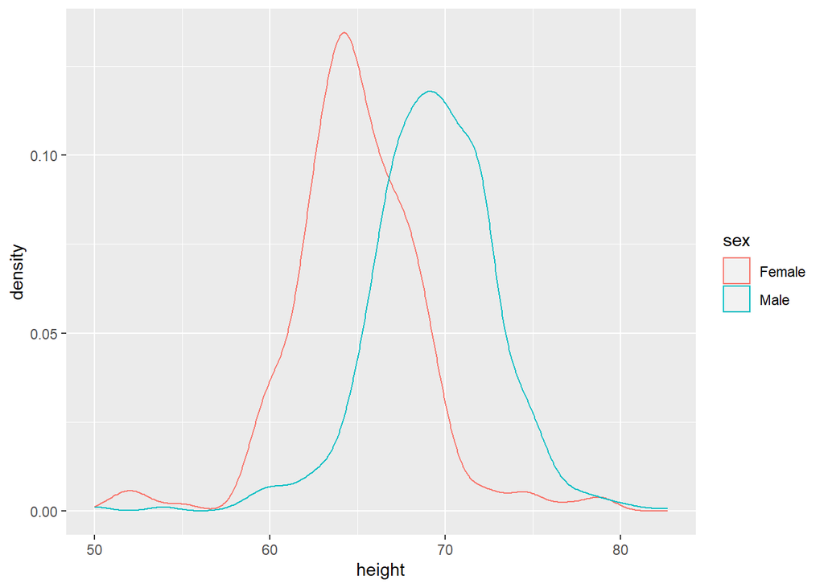

```r
heights %>% ggplot(aes(height, group=sex, colour=sex)) + geom_density()
```

```r
heights %>% group_by(sex) %>% summarise(n = n()) %>% ungroup() %>% mutate(p = round(100*n/sum(n),1))
```

```
## # A tibble: 2 x 3
##   sex        n     p
##   <fct>  <int> <dbl>
## 1 Female   238  22.7
## 2 Male     812  77.3
```

```r
# obtain delta in height densities between males and females
heights.min <- min(heights$height)
heights.max <- max(heights$height)
density.male <- density(heights %>% filter(sex == "Male") %>% pull(height), from=heights.min, to=heights.max)
density.female <- density(heights %>% filter(sex == "Female") %>% pull(height), from=heights.min, to=heights.max)
density.diff <- density.male$y - density.female$y
density.intersect <- density.male$x[which(diff(density.diff > 0) != 0) + 1][1]


# use a height cutoff to guess the gender instead of random guess
y_hat <- ifelse(x > density.intersect, "Male", "Female") %>% factor(levels = levels(test_set$sex))
test_set %>% summarise(accuracy = mean(y_hat == sex))
```

```
##    accuracy
## 1 0.5933333
```

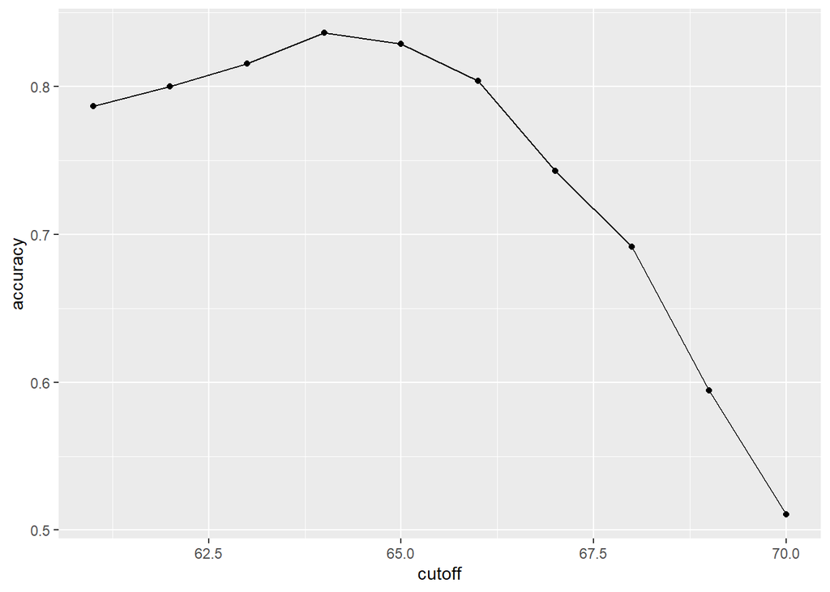

```r
# iterate over possible cutoff points
cutoff <- seq(61, 70)
accuracy <- map_dbl(cutoff, function(x){
  y_hat <- ifelse(train_set$height > x, "Male", "Female") %>%
    factor(levels = levels(test_set$sex))
  mean(y_hat == train_set$sex)
})
data.frame(cutoff, accuracy) %>%
  ggplot(aes(cutoff, accuracy)) +
  geom_point() +
  geom_line()
```

```r
max(accuracy)
```

```
## [1] 0.8361905
```

```r
best_cutoff <- cutoff[which.max(accuracy)]
best_cutoff
```

```
## [1] 64
```

```r
y_hat <- ifelse(test_set$height > best_cutoff, "Male", "Female") %>%
  factor(levels = levels(test_set$sex))
y_hat <- factor(y_hat)
mean(y_hat == test_set$sex)
```

```
## [1] 0.8171429
```

Notice that the success of our random guess approach is as expected, roughly **50%**. We improve upon this by using the cutoff which represents the intersection point of the densities, obtaining an accuracy of close to **60%**. We further improve about this by iterating over additional cutoff points on our training data to achieve an accuracy of **82%** on our test set with a cutoff height of 64.

Now we take a look at the confusion matrix and additional measures of accuracy.

**Sensitivity** (or *Recall*) is a measure of an algorithm’s ability to accurately predict a positive outcome. In other words, it is the percentage positive cases that are identified by the algorithm. This is calculated as:
$$Sensitivity=\frac{TP}{TP + FN}$$

**Specificity** is the measure of the algorithm’s ability to accurately predict a negative outcome. Similar to above, it is the percentage of negative cases that are identified by the algorithm. This is calculated as:
$$Specificity=\frac{TN}{TN + FP}$$

```r
# tabulate each combination of prediction and actual value
table(predicted = y_hat, actual = test_set$sex)
```

```
##          actual
## predicted Female Male
##    Female     50   27
##    Male       69  379
```

```r
test_set %>%
  mutate(y_hat = y_hat) %>%
  group_by(sex) %>%
  summarise(accuracy = mean(y_hat == sex))
```

```
## # A tibble: 2 x 2
##   sex    accuracy
##   <fct>     <dbl>
## 1 Female    0.420
## 2 Male      0.933
```

```r
prev <- mean(y == "Male")

confusionMatrix(data = y_hat, reference = test_set$sex)
```

```
## Confusion Matrix and Statistics
##
##           Reference
## Prediction Female Male
##     Female     50   27
##     Male       69  379
##
##                Accuracy : 0.8171
##                  95% CI : (0.7814, 0.8493)
##     No Information Rate : 0.7733
##     P-Value [Acc > NIR] : 0.008354
##
##                   Kappa : 0.4041
##
##  Mcnemar's Test P-Value : 2.857e-05
##
##             Sensitivity : 0.42017
##             Specificity : 0.93350
##          Pos Pred Value : 0.64935
##          Neg Pred Value : 0.84598
##              Prevalence : 0.22667
##          Detection Rate : 0.09524
##    Detection Prevalence : 0.14667
##       Balanced Accuracy : 0.67683
##
##        'Positive' Class : Female
##
```

Note that in situations where prevalence is low, precision becomes a more important metric. Precision is the given by the proportion of predicted positive cases that are actually positive. Formulaically:

$$Precision = \frac{TP}{TP+FP}$$

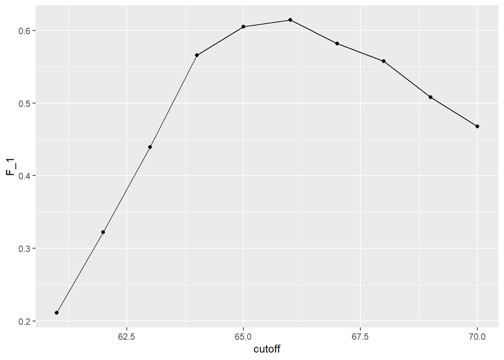

```r
# maximize F-score
cutoff <- seq(61, 70)
F_1 <- map_dbl(cutoff, function(x){
  y_hat <- ifelse(train_set$height > x, "Male", "Female") %>%
    factor(levels = levels(test_set$sex))
  F_meas(data = y_hat, reference = factor(train_set$sex))
})

data.frame(cutoff, F_1) %>%
  ggplot(aes(cutoff, F_1)) +
  geom_point() +
  geom_line()
```

```r
max(F_1)
```

```
## [1] 0.6142322
```

```r
best_cutoff <- cutoff[which.max(F_1)]
best_cutoff
```

```
## [1] 66
```

```r
y_hat <- ifelse(test_set$height > best_cutoff, "Male", "Female") %>%
  factor(levels = levels(test_set$sex))

confusionMatrix(data = y_hat, reference = test_set$sex)
```

```
## Confusion Matrix and Statistics
##
##           Reference
## Prediction Female Male
##     Female     81   67
##     Male       38  339
##
##                Accuracy : 0.8
##                  95% CI : (0.7632, 0.8334)
##     No Information Rate : 0.7733
##     P-Value [Acc > NIR] : 0.078192
##
##                   Kappa : 0.4748
##
##  Mcnemar's Test P-Value : 0.006285
##
##             Sensitivity : 0.6807
##             Specificity : 0.8350
##          Pos Pred Value : 0.5473
##          Neg Pred Value : 0.8992
##              Prevalence : 0.2267
##          Detection Rate : 0.1543
##    Detection Prevalence : 0.2819
##       Balanced Accuracy : 0.7578
##
##        'Positive' Class : Female
##
```

```r
p <- 0.9
n <- length(test_index)
y_hat <- sample(c("Male", "Female"), n, replace = TRUE, prob=c(p, 1-p)) %>%
  factor(levels = levels(test_set$sex))
mean(y_hat == test_set$sex)
```

```
## [1] 0.7161905
```

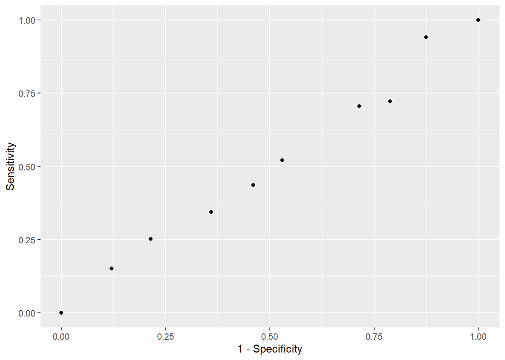

```r
# ROC curve
probs <- seq(0, 1, length.out = 10)
guessing <- map_df(probs, function(p){
  y_hat <-
    sample(c("Male", "Female"), n, replace = TRUE, prob=c(p, 1-p)) %>%
    factor(levels = c("Female", "Male"))
  list(method = "Guessing",
       FPR = 1 - specificity(y_hat, test_set$sex),
       TPR = sensitivity(y_hat, test_set$sex))
})
guessing %>% qplot(FPR, TPR, data =., xlab = "1 - Specificity", ylab = "Sensitivity")
```

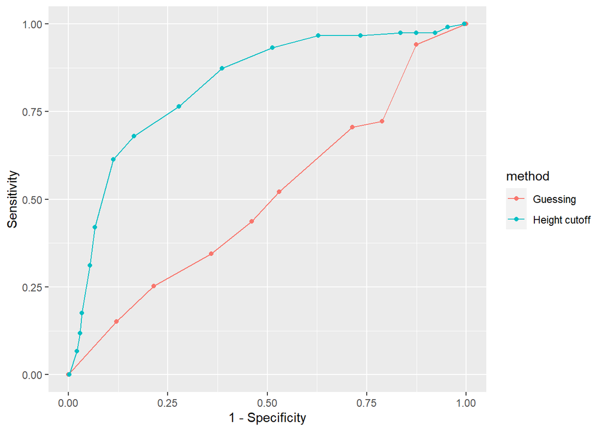

```r
cutoffs <- c(50, seq(60, 75), 80)
height_cutoff <- map_df(cutoffs, function(x){
  y_hat <- ifelse(test_set$height > x, "Male", "Female") %>%
    factor(levels = c("Female", "Male"))
   list(method = "Height cutoff",
        FPR = 1-specificity(y_hat, test_set$sex),
        TPR = sensitivity(y_hat, test_set$sex))
})

# plot both curves together
bind_rows(guessing, height_cutoff) %>%
  ggplot(aes(FPR, TPR, color = method)) +
  geom_line() +
  geom_point() +
  xlab("1 - Specificity") +
  ylab("Sensitivity")
```

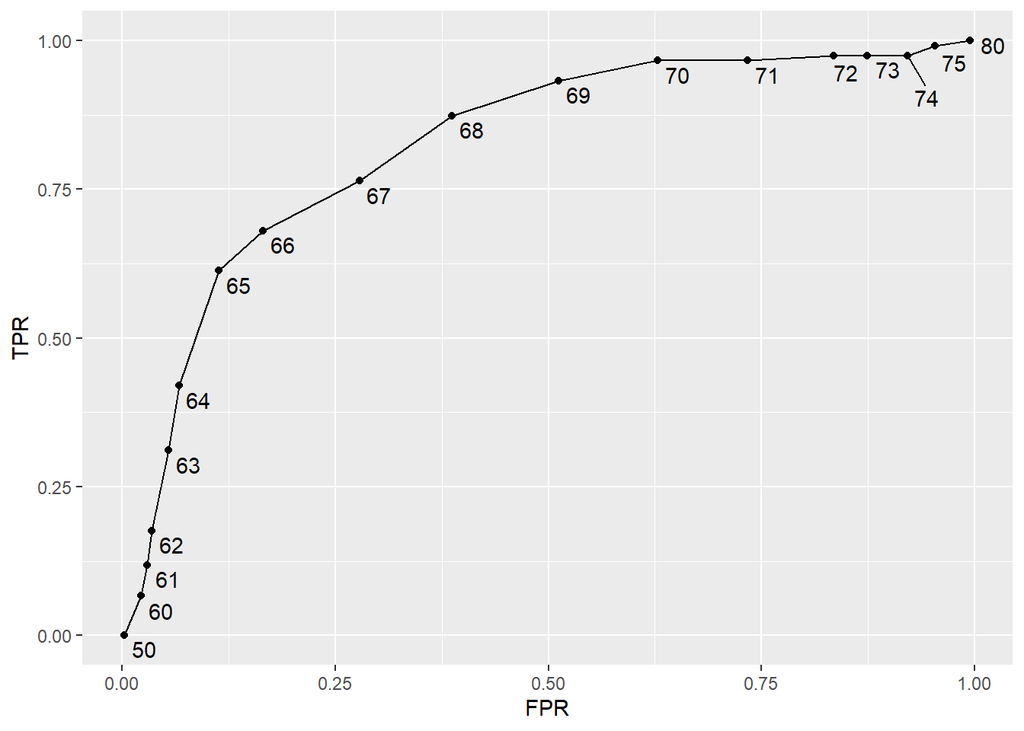

```r
library(ggrepel)
map_df(cutoffs, function(x){
  y_hat <- ifelse(test_set$height > x, "Male", "Female") %>%
    factor(levels = c("Female", "Male"))
   list(method = "Height cutoff",
        cutoff = x,
        FPR = 1-specificity(y_hat, test_set$sex),
        TPR = sensitivity(y_hat, test_set$sex))
}) %>%
  ggplot(aes(FPR, TPR, label = cutoff)) +
  geom_line() +
  geom_point() +
  geom_text_repel(nudge_x = 0.01, nudge_y = -0.01)
```

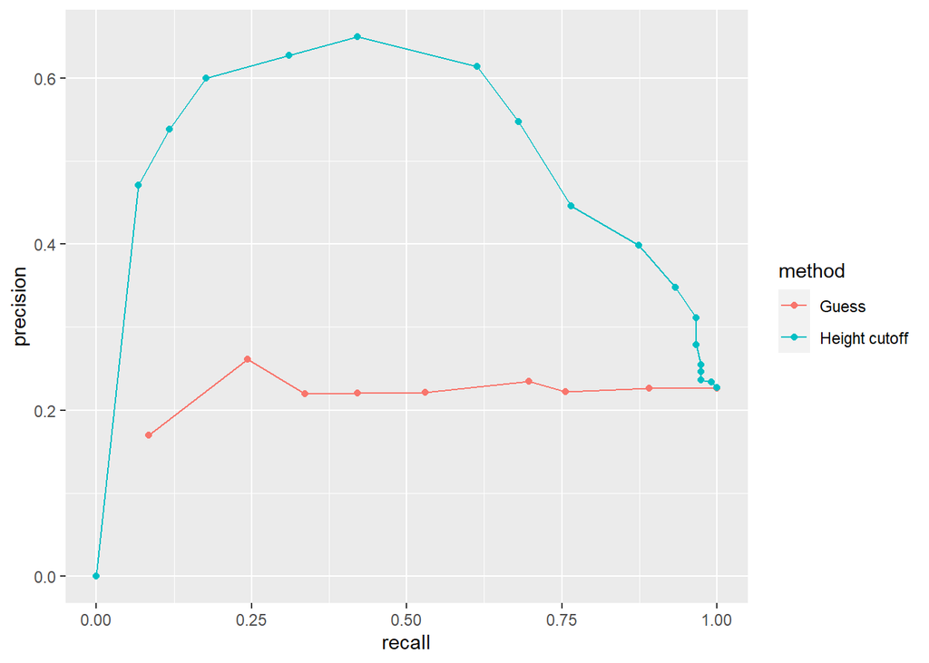

```r
# plot precision against recall
guessing <- map_df(probs, function(p){
  y_hat <- sample(c("Male", "Female"), length(test_index),
                  replace = TRUE, prob=c(p, 1-p)) %>%
    factor(levels = c("Female", "Male"))
  list(method = "Guess",
    recall = sensitivity(y_hat, test_set$sex),
    precision = precision(y_hat, test_set$sex))
})

height_cutoff <- map_df(cutoffs, function(x){
  y_hat <- ifelse(test_set$height > x, "Male", "Female") %>%
    factor(levels = c("Female", "Male"))
  list(method = "Height cutoff",
       recall = sensitivity(y_hat, test_set$sex),
    precision = precision(y_hat, test_set$sex))
})

bind_rows(guessing, height_cutoff) %>%
  ggplot(aes(recall, precision, color = method)) +
  geom_line() +
  geom_point()
```

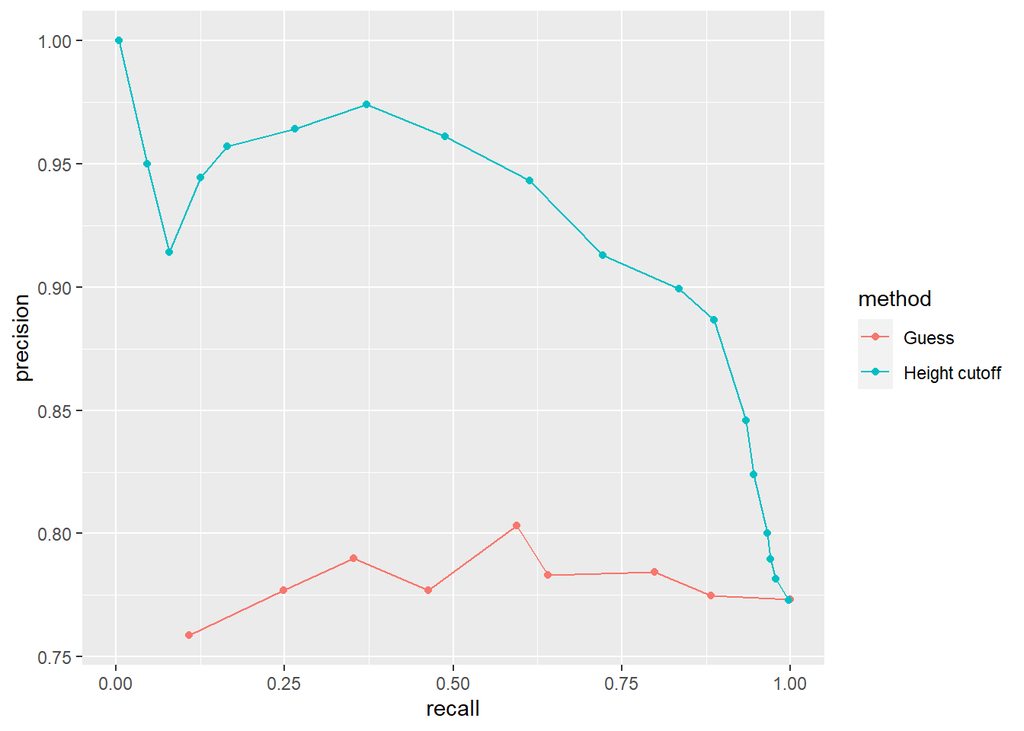

```r
guessing <- map_df(probs, function(p){
  y_hat <- sample(c("Male", "Female"), length(test_index), replace = TRUE,
                  prob=c(p, 1-p)) %>%
    factor(levels = c("Male", "Female"))
  list(method = "Guess",
    recall = sensitivity(y_hat, relevel(test_set$sex, "Male", "Female")),
    precision = precision(y_hat, relevel(test_set$sex, "Male", "Female")))
})

height_cutoff <- map_df(cutoffs, function(x){
  y_hat <- ifelse(test_set$height > x, "Male", "Female") %>%
    factor(levels = c("Male", "Female"))
  list(method = "Height cutoff",
       recall = sensitivity(y_hat, relevel(test_set$sex, "Male", "Female")),
    precision = precision(y_hat, relevel(test_set$sex, "Male", "Female")))
})
bind_rows(guessing, height_cutoff) %>%
  ggplot(aes(recall, precision, color = method)) +
  geom_line() +
  geom_point()
```

### Comprehension Check

```r
dat <- mutate(reported_heights, date_time = ymd_hms(time_stamp)) %>%
  filter(date_time >= make_date(2016, 01, 25) & date_time < make_date(2016, 02, 1)) %>%
  mutate(type = ifelse(day(date_time) == 25 & hour(date_time) == 8 & between(minute(date_time), 15, 30), "inclass","online")) %>%
  select(sex, type)

y <- factor(dat$sex, c("Female", "Male"))
x <- dat$type

data(iris)
iris <- iris[-which(iris$Species=='setosa'),]
y <- iris$Species
```

```r
dat %>% group_by(type, sex) %>% summarise(n = n()) %>% mutate(p = n/sum(n))
```

```
## # A tibble: 4 x 4
## # Groups:   type [2]
##   type    sex        n     p
##   <chr>   <chr>  <int> <dbl>
## 1 inclass Female    26 0.667
## 2 inclass Male      13 0.333
## 3 online  Female    42 0.378
## 4 online  Male      69 0.622
```

```r
prediction <- dat %>%
  group_by(type, sex) %>%
  summarise(n = n()) %>%
  mutate(p = n/sum(n), max_p = max(n/sum(n))) %>%
  filter(p == max_p) %>%
  ungroup() %>%
  select(type, sex)

dat <- dat %>%
  left_join(prediction, by = c("type"))

dat %>%
  mutate(correct = sex.x == sex.y) %>%
  summarise(accuracy = mean(correct))
```

```
##    accuracy
## 1 0.6333333
```

```r
table(dat$sex.x, dat$sex.y)
```

```
##
##          Female Male
##   Female     26   42
##   Male       13   69
```

```r
sensitivity(as.factor(dat$sex.y), as.factor(dat$sex.x))
```

```
## [1] 0.3823529
```

```r
specificity(as.factor(dat$sex.y), as.factor(dat$sex.x))
```

```
## [1] 0.8414634
```

```r
dat %>% group_by(sex.x) %>% summarise(n = n()) %>% mutate(p = n/sum(n))
```

```
## # A tibble: 2 x 3
##   sex.x      n     p
##   <chr>  <int> <dbl>
## 1 Female    68 0.453
## 2 Male      82 0.547
```

```r
# set.seed(2) # if using R 3.5 or earlier
set.seed(2, sample.kind="Rounding") # if using R 3.6 or later
test_index <- createDataPartition(y,times=1,p=0.5,list=FALSE)
test <- iris[test_index,]
train <- iris[-test_index,]
```

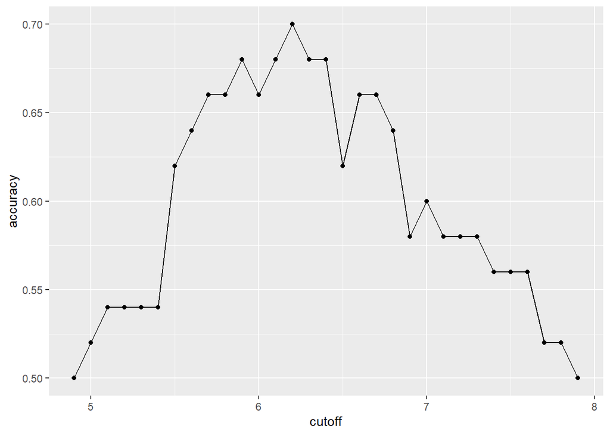

```r
# Sepal Length Predictor
cutoff <- seq(min(iris$Sepal.Length),max(iris$Sepal.Length),0.1)

accuracy <- map_dbl(cutoff, function(x){
  y_hat <- ifelse(train$Sepal.Length > x, "virginica", "versicolor") %>%
    factor(levels = levels(train$Species))
  mean(y_hat == train$Species)
})

data.frame(cutoff, accuracy) %>%
  ggplot(aes(cutoff, accuracy)) +
  geom_point() +
  geom_line()
```

```r
max(accuracy)
```

```
## [1] 0.7
```

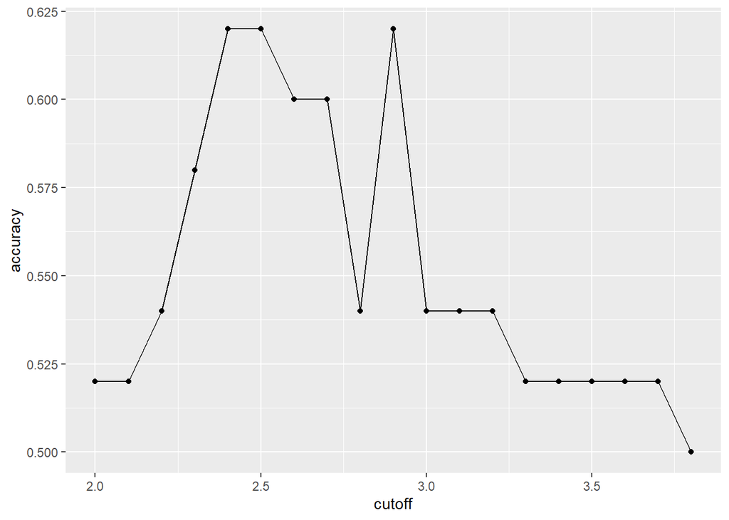

```r
# Sepal Width Predictor
cutoff <- seq(min(iris$Sepal.Width),max(iris$Sepal.Width),0.1)

accuracy <- map_dbl(cutoff, function(x){
  y_hat <- ifelse(train$Sepal.Width > x, "virginica", "versicolor") %>%
    factor(levels = levels(train$Species))
  mean(y_hat == train$Species)
})

data.frame(cutoff, accuracy) %>%
  ggplot(aes(cutoff, accuracy)) +
  geom_point() +
  geom_line()
```

```r
max(accuracy)
```

```
## [1] 0.62
```

```r
# Petal Length Predictor

cutoff <- seq(min(iris$Petal.Length),max(iris$Petal.Length),0.1)

accuracy <- map_dbl(cutoff, function(x){
  y_hat <- ifelse(train$Petal.Length > x, "virginica", "versicolor") %>%
    factor(levels = levels(train$Species))
  mean(y_hat == train$Species)
})

data.frame(cutoff, accuracy) %>%
  ggplot(aes(cutoff, accuracy)) +
  geom_point() +
  geom_line()
```

[output not shown]

```r
max(accuracy)
```

```
## [1] 0.96
```

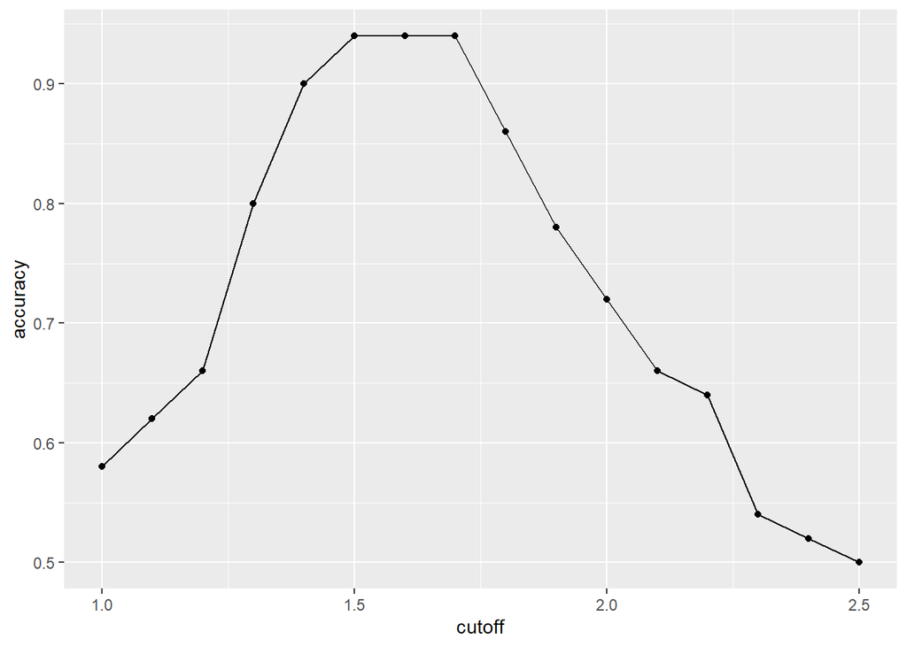

```r
# Petal Width Predictor

cutoff <- seq(min(iris$Petal.Width),max(iris$Petal.Width),0.1)

accuracy <- map_dbl(cutoff, function(x){
  y_hat <- ifelse(train$Petal.Width > x, "virginica", "versicolor") %>%
    factor(levels = levels(train$Species))
  mean(y_hat == train$Species)
})

data.frame(cutoff, accuracy) %>%
  ggplot(aes(cutoff, accuracy)) +
  geom_point() +
  geom_line()
```

```r
max(accuracy)
```

```
## [1] 0.94
```

```r
cutoff <- seq(min(iris$Petal.Length),max(iris$Petal.Length),0.1)

accuracy <- map_dbl(cutoff, function(x){
  y_hat <- ifelse(train$Petal.Length > x, "virginica", "versicolor") %>%
    factor(levels = levels(train$Species))
  mean(y_hat == train$Species)
})

data.frame(cutoff, accuracy) %>%
  ggplot(aes(cutoff, accuracy)) +
  geom_point() +
  geom_line()
```

[output not shown]

```r
max(accuracy)
```

```
## [1] 0.96
```

```r
smart_cutoff <- min(cutoff[accuracy == max(accuracy)])

y_hat <- ifelse(test$Petal.Length > smart_cutoff, "virginica", "versicolor") %>% factor(levels = levels(test$Species))
mean(y_hat == test$Species)
```

```
## [1] 0.9
```

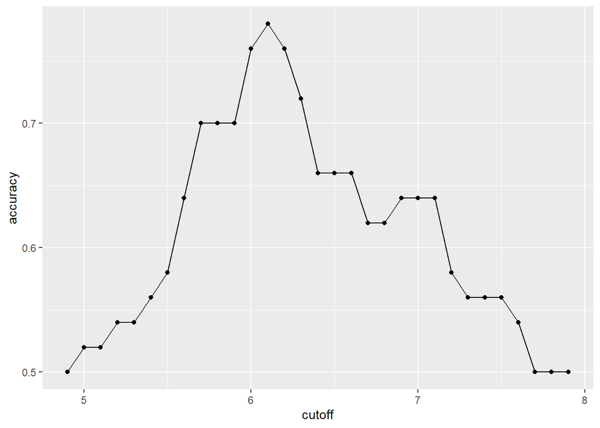

```r
# Sepal Length Predictor
cutoff <- seq(min(iris$Sepal.Length),max(iris$Sepal.Length),0.1)

accuracy <- map_dbl(cutoff, function(x){
  y_hat <- ifelse(test$Sepal.Length > x, "virginica", "versicolor") %>%
    factor(levels = levels(test$Species))
  mean(y_hat == test$Species)
})

data.frame(cutoff, accuracy) %>%
  ggplot(aes(cutoff, accuracy)) +
  geom_point() +
  geom_line()
```

```r
max(accuracy)
```

```
## [1] 0.78
```

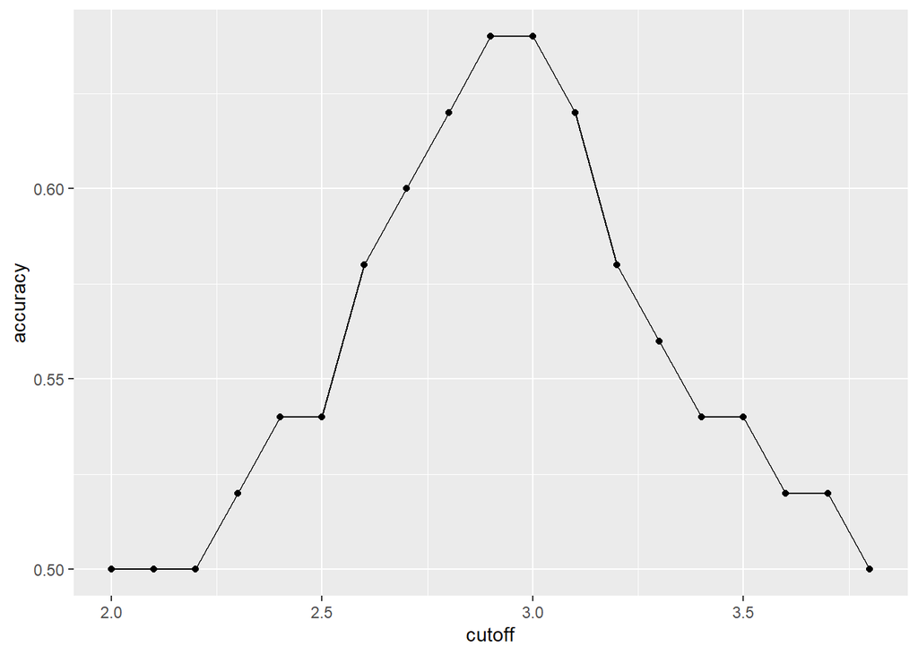

```r
# Sepal Width Predictor
cutoff <- seq(min(iris$Sepal.Width),max(iris$Sepal.Width),0.1)

accuracy <- map_dbl(cutoff, function(x){
  y_hat <- ifelse(test$Sepal.Width > x, "virginica", "versicolor") %>%
    factor(levels = levels(test$Species))
  mean(y_hat == test$Species)
})

data.frame(cutoff, accuracy) %>%
  ggplot(aes(cutoff, accuracy)) +
  geom_point() +
  geom_line()
```

```r
max(accuracy)
```

```
## [1] 0.64
```

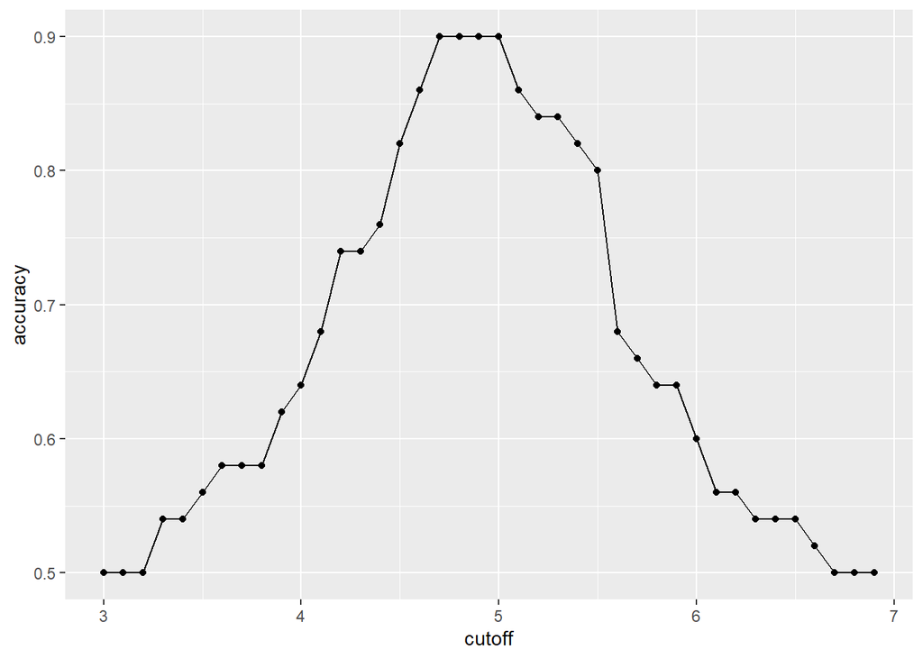

```r
# Petal Length Predictor

cutoff <- seq(min(iris$Petal.Length),max(iris$Petal.Length),0.1)

accuracy <- map_dbl(cutoff, function(x){
  y_hat <- ifelse(test$Petal.Length > x, "virginica", "versicolor") %>%
    factor(levels = levels(test$Species))
  mean(y_hat == test$Species)
})

data.frame(cutoff, accuracy) %>%
  ggplot(aes(cutoff, accuracy)) +
  geom_point() +
  geom_line()
```

```r
max(accuracy)
```

```
## [1] 0.9
```

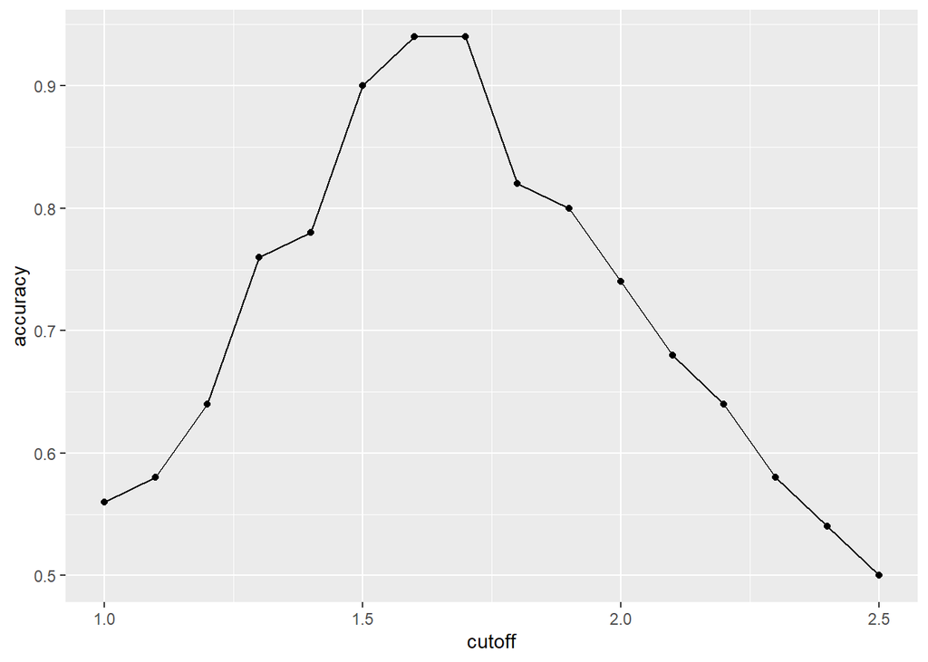

```r
# Petal Width Predictor

cutoff <- seq(min(iris$Petal.Width),max(iris$Petal.Width),0.1)

accuracy <- map_dbl(cutoff, function(x){
  y_hat <- ifelse(test$Petal.Width > x, "virginica", "versicolor") %>%
    factor(levels = levels(test$Species))
  mean(y_hat == test$Species)
})

data.frame(cutoff, accuracy) %>%
  ggplot(aes(cutoff, accuracy)) +
  geom_point() +
  geom_line()
```

```r
max(accuracy)
```

```
## [1] 0.94
```

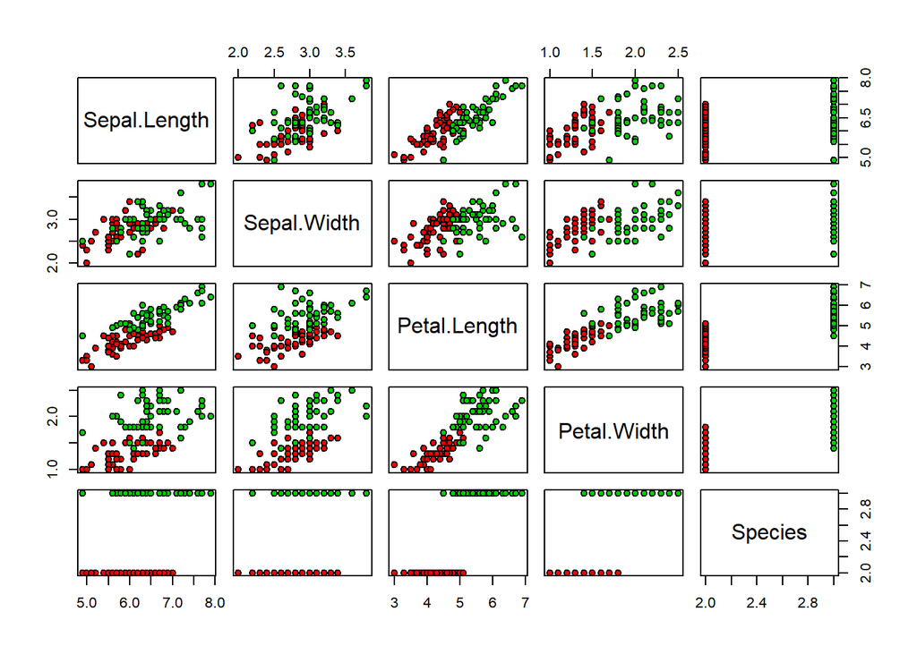

```r
# what does this plot do?
plot(iris,pch=21,bg=iris$Species)
```

```r
# Petal Length Predictor

cutoff <- seq(min(iris$Petal.Length),max(iris$Petal.Length),0.1)

accuracy <- map_dbl(cutoff, function(x){
  y_hat <- ifelse(train$Petal.Length > x, "virginica", "versicolor") %>%
    factor(levels = levels(train$Species))
  mean(y_hat == train$Species)
})

data.frame(cutoff, accuracy) %>%
  ggplot(aes(cutoff, accuracy)) +
  geom_point() +
  geom_line()
```

[output not shown]

```r
max(accuracy)
```

```
## [1] 0.96
```

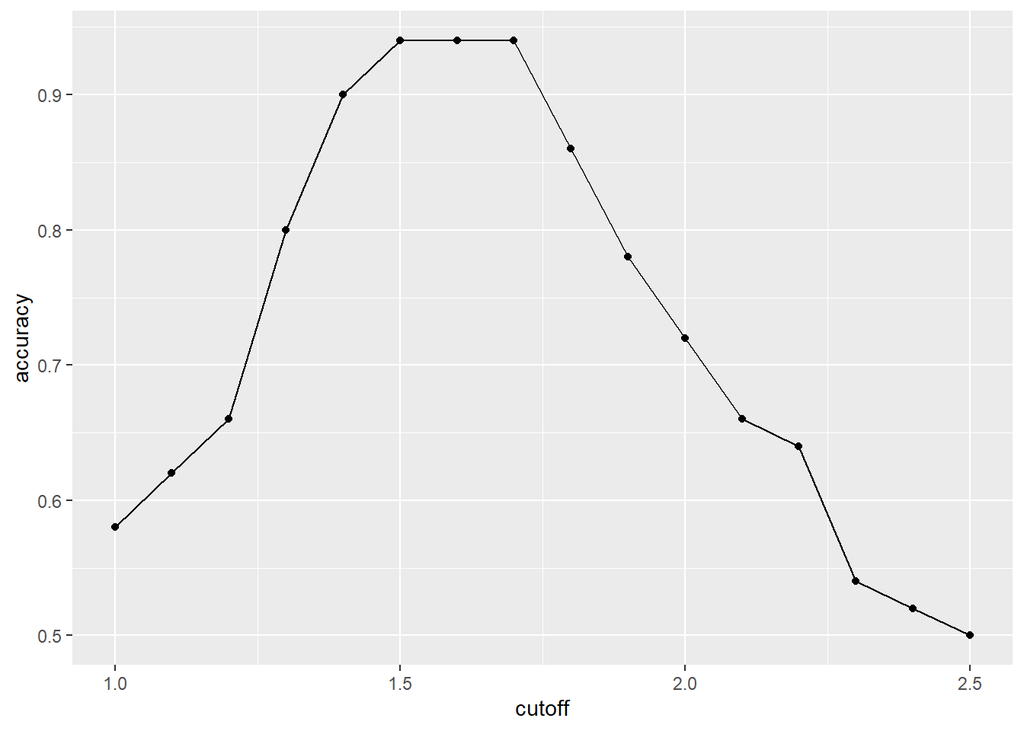

```r
PL_cutoff <- min(cutoff[accuracy == max(accuracy)])

# Petal Width Predictor

cutoff <- seq(min(iris$Petal.Width),max(iris$Petal.Width),0.1)

accuracy <- map_dbl(cutoff, function(x){
  y_hat <- ifelse(train$Petal.Width > x, "virginica", "versicolor") %>%
    factor(levels = levels(train$Species))
  mean(y_hat == train$Species)
})

data.frame(cutoff, accuracy) %>%
  ggplot(aes(cutoff, accuracy)) +
  geom_point() +
  geom_line()
```

```r
max(accuracy)
```

```
## [1] 0.94
```

```r
PW_cutoff <- min(cutoff[accuracy == max(accuracy)])


y_hat <- ifelse(test$Petal.Length > PL_cutoff | test$Petal.Width > PW_cutoff, "virginica", "versicolor") %>% factor(levels = levels(test$Species))
mean(y_hat == test$Species)
```

```
## [1] 0.88
```

### Section 2.2: Conditional Probabilities